# Clusters and Mapping

## GIS & clustering

For spatial analysis, several base layers and functions are provided for mapping and clustering detection. The R package “sf” is used in most spatial transformations and analysis. Geo coded data can be mapped both statically and interactively.

The named list variable `geo_sets` stores paths to often used base layers. For example `geo_sets$isd` returns the path to a layer of independent school districts. The next table shows the name and the layer available, all of which are polygons stored as “sf” objects and have a coordinate reference system set `epsg:4326`

| Name | Layer |
| --- | --- |
| ZCTA | Tarrant Zip Code Tabulation Areas |
| tarrant_border | Tarrant County boundaries as a polygon |
| tarrant_tracts | Census tracts in Tarrant County |
| tarrant_blocks | Census blocks in Tarrant County |
| tarrant_cities | Boundaries of partially or wholly contained cities |
| surrounding_borders | Borders of counties surrounding Tarrant |
| isd | Independent School Districts |

Each of the layers can be loaded using `load_tarrant_spatial()` or `readRDS()`. The load_tarrant_spatial(.name, .crs) takes one of the names in the table above and by default returns the layer with a Coordinate Reference System (CRS) of ‘4326’. The `crs` can be used to have the spatial layer in a different coordinate reference system. You can also use the base R function readRDS() and give it the path to the layer using the geo_sets list varibale. Here is how each method can be used to load a layer.

```r
library(tarr,  quietly = TRUE)
library(sf,    quietly = TRUE)
```

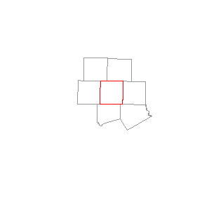

```r
# load and add city boundaries using readRDS and geo_sets
other_counties <- readRDS(file = geo_sets$surrounding_borders)
plot(x = st_geometry(other_counties), border = "grey60")

# load the Tarrant County border then add it to the map
tarr_border <- load_tarrant_spatial("tarrant_border")
plot(x = st_geometry(tarr_border), border = "red", add = TRUE )
```

```r
rm(cities, other_counties, tarr_border)
```

## Mapping cases

Line lists of cases with latititude and longitude data can be mapped. Importantly, case lists from EpiTtax can include the lat/lon the residence of each case. For example, usng the package provided synthtic_outbreak data frame, make it a simple fetures (sf) POINTS object that can be mapped using the `st_as_sf()` function.

Several base map tiles from Google maps and Stadiamaps are also available in the package. These can be used for background to give points context in a non-interactive map. The tiles are stored in a list called base_map[.]

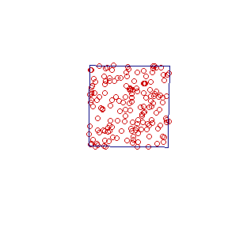

```r
# get theTarrant County outline
county  <- load_tarrant_spatial("tarrant_border")

# Select the fooflu cases and make it an sf POINTS object
foo <- synthetic_outbreak[synthetic_outbreak$condition == "fooflu",] |>
  st_as_sf(coords = c("lon", "lat"))

# foo needs a crs, assign it from the county sf object
st_crs(foo) = st_crs(county)

# plot the "cases"  and county outline
plot(st_geometry(foo), col = "red3")
plot(st_geometry(county), add = TRUE, border = "navyblue", col = NA)
```

A static map

## Density based algorithms are provided for identifying possiblespatial clusters.

```r
foo_scan <- scan_cluster(points = foo, method = "HDBSCAN", eps = 5280*1.25, minPts = 7)
foo_scan
```

```
#>
#> <clustered>
#> HDBSCAN clustering for 162 observations.
#> Containing 5 cluster(s) and 83 noise points.
#> Simple feature collection with 162 features and 11 fields
#> Geometry type: POINT
#> Dimension:     XY
#> Bounding box:  xmin: -97.5498 ymin: 32.54936 xmax: -97.0332 ymax: 32.99349
#> Geodetic CRS:  WGS 84
#> # A tibble: 162 × 12
#>   condition sex    outcome race  onset      dob                    geometry
#> * <chr>     <chr>  <chr>   <chr> <date>     <date>              <POINT [°]>
#> 1 fooflu    female Recover white 2020-01-01 1947-05-11 (-97.07544 32.79086)
#> 2 fooflu    male   Recover white 2020-01-08 1952-05-18 (-97.09343 32.75527)
#> 3 fooflu    male   Death   other 2020-01-10 1939-05-20 (-97.45542 32.55627)
#> 4 fooflu    male   Recover white 2020-01-15 1969-05-25   (-97.2638 32.6062)
#> 5 fooflu    female Recover white 2020-01-15 1965-05-25 (-97.14414 32.77273)
#> 6 fooflu    male   Death   white 2020-01-14 1944-05-24 (-97.21059 32.64628)
#> 7 fooflu    female Recover paci… 2020-01-11 1987-05-21 (-97.48393 32.63046)
#> # ℹ 155 more rows
#> # ℹ 5 more variables: cluster <fct>, .coredist <dbl>, .membership_prob <dbl>,
#> #   .outlier_scores <dbl>, point_type <chr>
```

```r
# show the cases and clusters
plot(foo_scan)
```

[interactive chart not shown]

```r
# Optional basemap layers

spat <- load_tarrant_spatial()

# Ensure geometry
# cases_sf <- sf::st_as_sf(nbs, coords = c(lon,lat), crs = 4326)

# Cluster (example: HDBSCAN)
cl <- scan_cluster(
  x = cases_sf,
  method = hdbscan,
  minPts = 5
)

# Visualize (ggplot)
autoplot(cl) + map_theme

# Or with tmap
plot(cl)

# Inspect clustering internals
scan_object(cl)
get_unit(cl)
```

**Tips** - Prefer a projected CRS for distance-based clustering (choose one appropriate for your county/state). - HDBSCAN handles variable density better; DBSCAN is fast for well-separated clusters.